# Code for JPR

This document reproduces the TopPICR workflow and statistical analysis on the CPTAC human-in-mouse xenograft breast cancer data. It takes 4-5 minutes to run all the code to reproduce the analysis, figures, and tables. All the R code used to produce this document can be shown with the button in the top right. Alternatively, individual sections of code can be shown/hidden with the buttons throughout the document on the right hand side of the page.

# Code for TopPICR pipeline

The following sections demonstrate a typical TopPICR workflow. The code blocks are separated into several main steps: read TopPIC output into R, identified (or MS2) steps, unidentified (or MS1) steps, match-between-runs (MBR), convert TopPICR output into an MSnSet object, and statistical analysis.

## Read in TopPIC output

```r
# Read in the identified or MS2 data -------------------------------------------

# NOTE: Be sure to update the path to the cloned repo by changing the working
# directory in the R session or by updating the path object (the_path).

the_path <- "."

ms2 <- read_toppic(
  file_path = file.path(the_path, "TopPIC_output/"),
  file_name = c(
    "CPTAC_Intact_CR32B_24Aug15_Bane_15-02-06-RZ_ms2_toppic_prsm.tsv",
    "CPTAC_Intact_CR32C_24Aug15_Bane_15-02-06-RZ_ms2_toppic_prsm.tsv",
    "CPTAC_Intact_CR32D_24Aug15_Bane_15-02-06-RZ_ms2_toppic_prsm.tsv",
    "CPTAC_Intact_CR32E_24Aug15_Bane_15-02-06-RZ_ms2_toppic_prsm.tsv",
    "CPTAC_Intact_CR32F_24Aug15_Bane_15-02-06-RZ_ms2_toppic_prsm.tsv",
    "CPTAC_Intact_CR33B_24Aug15_Bane_15-02-06-RZ_ms2_toppic_prsm.tsv",
    "CPTAC_Intact_CR33C_24Aug15_Bane_15-02-06-RZ_ms2_toppic_prsm.tsv",
    "CPTAC_Intact_CR33D_24Aug15_Bane_15-02-06-RZ_ms2_toppic_prsm.tsv",
    "CPTAC_Intact_CR33E_24Aug15_Bane_15-02-06-RZ_ms2_toppic_prsm.tsv",
    "CPTAC_Intact_CR33F_24Aug15_Bane_15-02-06-RZ_ms2_toppic_prsm.tsv"
  ),
  faims = FALSE
)

# Read in the unidentified or MS1 data -----------------------------------------

ms1 <- read_toppic(
  file_path = file.path(the_path, "TopPIC_output/"),
  file_name = c(
    "CPTAC_Intact_CR32B_24Aug15_Bane_15-02-06-RZ_ms1.feature",
    "CPTAC_Intact_CR32C_24Aug15_Bane_15-02-06-RZ_ms1.feature",
    "CPTAC_Intact_CR32D_24Aug15_Bane_15-02-06-RZ_ms1.feature",
    "CPTAC_Intact_CR32E_24Aug15_Bane_15-02-06-RZ_ms1.feature",
    "CPTAC_Intact_CR32F_24Aug15_Bane_15-02-06-RZ_ms1.feature",
    "CPTAC_Intact_CR33B_24Aug15_Bane_15-02-06-RZ_ms1.feature",
    "CPTAC_Intact_CR33C_24Aug15_Bane_15-02-06-RZ_ms1.feature",
    "CPTAC_Intact_CR33D_24Aug15_Bane_15-02-06-RZ_ms1.feature",
    "CPTAC_Intact_CR33E_24Aug15_Bane_15-02-06-RZ_ms1.feature",
    "CPTAC_Intact_CR33F_24Aug15_Bane_15-02-06-RZ_ms1.feature"
  ),
  faims = FALSE
)
```

## MS2 steps

```r
# Identified feature (MS2) steps -----------------------------------------------

# Remove features that occur across multiple genes. The feature with the lowest
# E-value is kept.
ms2_rfg <- rm_false_gene(x = ms2)

# Update information for each proteoform (e.g., parent protein length,
# first/last amino acid position, and percent coverage of the parent protein).
ms2_mp <- map_proteoform(
  x = ms2_rfg,
  fst_path = file.path(the_path, "FASTA/"),
  fst_name = "human_mouse.fasta.gz"
)

# Filter proteoforms with low counts.
ms2_fbc <- filter_by_count(
  x = ms2_mp,
  count_within = c("Dataset", "Scan(s)"),
  count = "cleanSeq",
  threshold = 2
)

# Determine an E-value cutoff for each annotation type (SwissProt, VarSplic, and
# TrEMBL) that results in an FDR below the given threshold.
the_cutoff <- find_evalue_cutoff(
  x = ms2_fbc,
  fdr_threshold = 0.01
)

# Control the FDR level by applying the E-value cutoff calculated in the
# previous step.
ms2_fdr <- apply_evalue_cutoff(
  x = ms2_fbc,
  e_vals = the_cutoff
)

# Infer a minimal set of protein sequences.
ms2_ipf <- infer_prot(ms2_fdr)

# Determine the proteoform level for each proteoform.
ms2_pfl <- set_pf_level(ms2_ipf)

# Create a LOESS model for each data set that will be used to align the
# retention times to a reference data set.
the_model <- form_model(
  x = ms2_ipf,
  ref_ds = find_ref_ds(x = ms2_ipf),
  control = loess.control(surface = "direct"), # Use direct to avoid NAs.
  span = 0.5,
  family = "symmetric"
)

# Apply the LOESS model to align the retention times from each data set to the
# reference data set.
ms2_art <- align_rt(
  x = ms2_ipf,
  model = the_model,
  var_name = "Feature apex"
)

# Compute the error (difference) between the theoretical and observed mass
# within each data set and calculate the standard deviation of the error for
# both the retention time and mass.
the_error <- calc_error(
  x = ms2_art,
  ref_ds = find_ref_ds(x = ms2_ipf)
)

# Recalibrate the mass using the errors computed in the previous step.
ms2_rcm <- recalibrate_mass(
  x = ms2_art,
  errors = the_error,
  var_name = "Precursor mass"
)

# Cluster proteoforms in retention time and mass space.
ms2_clu <- cluster(
  x = ms2_rcm,
  errors = the_error,
  method = "single",
  height = 4,
  min_size = 2
)

# Group clusters based on cluster centroids and accounting for isotopic errors.
ms2_grp <- create_pcg(
  x = ms2_clu,
  errors = the_error,
  n_mme_sd = 3.163452,
  n_Da = 4,
  n_rt_sd = 3.001538
)

# Create a data matrix with meta data for each proteoform. This will be used as
# the featureData object when creating an MSnSet object at the end of the
# pipeline.
meta <- create_mdata(
  x = ms2_grp,
  errors = the_error,
  n_mme_sd = 3.163452,
  n_rt_sd = 3.001538
)
```

## MS1 steps

```r
# Unidentified feature (MS1) steps ---------------------------------------------

# Align the unidentified feature retention times using the model created with
# the identified feature retention times.
ms1_art <- align_rt(
  x = ms1,
  model = the_model,
  var_name = "Time_apex"
)

# Recalibrate the unidentified feature masses using the mass measurement errors
# calculated from the identified feature masses.
ms1_rcm <- recalibrate_mass(
  x = ms1_art,
  errors = the_error,
  var_name = "Mass"
)

# Recover unidentified features. This step matches unidentified features with
# cluster groups based on an envelope around each cluster centroid.
ms1_ms2 <- match_features(
  ms2 = ms2_grp,
  ms1 = ms1_rcm,
  errors = the_error,
  n_mme_sd = 3.163452,
  n_rt_sd = 3.001538,
  summary_fn = "max"
)
```

## Convert to MSnSet

```r
# Create MSnSet object ---------------------------------------------------------

# Combine the expression data (ms1_ms2) with the feature data (meta) to create
# an MSnSet object.
m <- to_msnset(ms1_ms2, meta)
```

## Statistical analysis

```r
# Run statistical analysis -----------------------------------------------------
m0 <- m

# preprocessing and normalization
exprs(m) <- log2(exprs(m))
exprs(m) <- sweep(exprs(m), 1, apply(exprs(m), 1, median, na.rm=T), FUN="-")

m <- normalizeByGlob(m)

m <- normalize_by_feature_property(m, property = "rt", method = "loess")

sum(is.na(exprs(m)))/(nrow(m) * ncol(m))

# add group variable to pData
p_data <- data.frame(sample_name = sampleNames(m),
                     row.names = sampleNames(m))

p_data <- p_data %>%
  mutate(group = sub("(CR3[23]).", "\\1", sample_name))

pData(m) <- p_data

res <- limma_a_b(m, "~ group", "group")

table(res$adj.P.Val < 0.05) # 1291 significant

res <- res %>%
  mutate(point_color = case_when(
    adj.P.Val < 0.05 & logFC < 0 ~ "down", # significantly down
    adj.P.Val < 0.05 & logFC > 0 ~ "up", # significantly up
    TRUE ~ "NS") # not significant
  )
```

# Code to reproduce figures

## Figure 2

The following four sections contain the code to reproduce each of the retention time alignment and mass measurement error plots.

### 2a

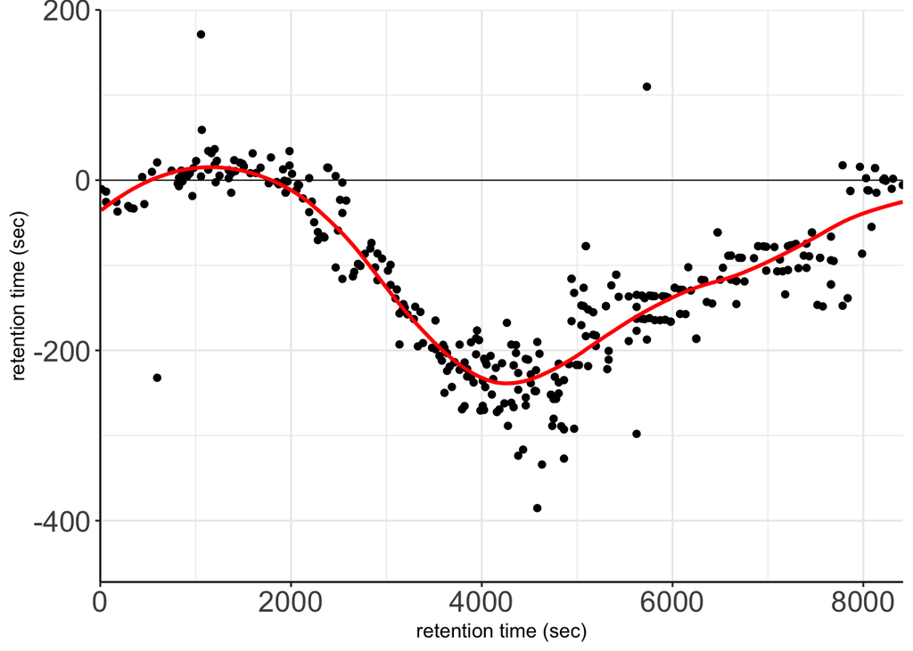

```r
ds_names <- names(the_model)

# We use CPTAC_Intact_CR33C_24Aug15_Bane_15-02-06-RZ (the seventh data set in
# ds_names) because it deviated the most from the reference.
cur_ds <- 7

# Find the corresponding aligned retention times -------------------------------

# Grab the reference and current data sets. This will be used to find the
# proteoforms that occur in both the reference data set (CR32C) and the current
# data set (CR33C).
ref_ds <- find_ref_ds(ms2_art)
cur_ds <- ds_names[[cur_ds]]

# Subset the original data set into the reference and current data sets.
x_ref <- ms2_ipf %>%
  filter(Dataset == ref_ds) %>%
  dplyr::distinct(`Feature intensity`, `Feature apex`, Proteoform) %>%
  dplyr::group_by(Proteoform) %>%
  dplyr::slice_max(`Feature intensity`) %>%
  dplyr::slice_min(`Feature apex`)
x_cur <- ms2_art %>%
  filter(Dataset == cur_ds) %>%
  dplyr::distinct(
    `Feature intensity`, `Feature apex`, Proteoform, RTalign
  ) %>%
  dplyr::group_by(Proteoform) %>%
  dplyr::slice_max(`Feature intensity`) %>%
  dplyr::slice_min(`Feature apex`)

# Find the proteoforms that occur in both CR32C and CR33C. This vector will be
# used to subset the aligned retention times from the current data matrix.
both <- intersect(x_ref$Proteoform, x_cur$Proteoform)

# Extract the indices where the intersecting Proteoforms occur in both the
# reference data set and the current data set.
idx_ref <- which(x_ref$Proteoform %in% both)
idx_cur <- which(x_cur$Proteoform %in% both)

aligned <- x_cur$RTalign[idx_cur]

# Plot the RTalign against the residuals from the model ------------------------

z <- data.frame(
  reference = x_ref$`Feature apex`[idx_ref],
  current = x_cur$`Feature apex`[idx_cur]
)

z$predicted <- predict(the_model[[cur_ds]], newdata = z$current)
z$predicted_line <- z$predicted - z$current

ggplot(
  z,
  aes(x = current, y = reference - current)
) +
  geom_point() +
  theme_bw() +
  theme(panel.border = element_blank(),
        axis.line = element_line(colour = "black"),
        axis.text = element_text(size = 16),
        strip.background = element_rect(colour = "white",
                                        fill = "white")) +
  scale_x_continuous(expand = c(0, 0), limits = c(0, 8417)) +
  scale_y_continuous(expand = c(0, 0), limits = c(-472, 200)) +
  geom_hline(yintercept = 0, color = "black", size = 0.3) +
  geom_line(aes(y = predicted_line),
            color = "red",
            size = 1) +
  xlab("retention time (sec)") +
  ylab("retention time (sec)")
```

### 2b

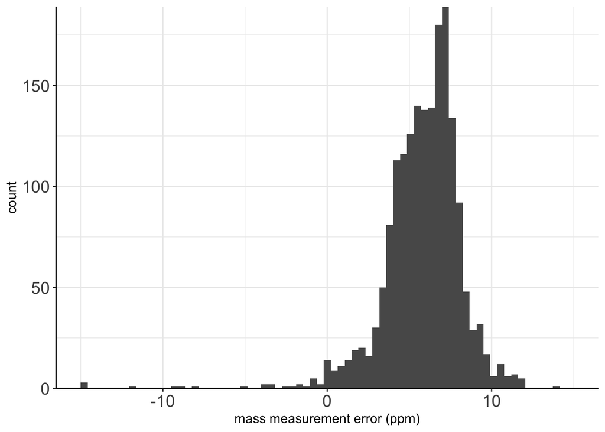

```r
# PPM error --------------------------------------------------------------------

# Only plot CR33C to match the rt alignment plot.
ms2_rcm %>%
  dplyr::mutate(
    split_dataset = str_split(Dataset, "_"),
    Dataset = map(split_dataset, `[[`, 3),
    Dataset = as.character(Dataset),
    ppm_error = 1e6 * (`Precursor mass` - `Adjusted precursor mass`) /
      `Adjusted precursor mass`
  ) %>%
  filter(Dataset == "CR33C") %>%
  ggplot(aes(x = ppm_error)) +
  geom_histogram(bins = 72) +
  xlim(c(-15, 15)) +
  xlab("Parts per million") +
  ylab("Count") +
  theme_bw() +
  theme(panel.border = element_blank(),
        axis.line = element_line(colour = "black"),
        axis.text = element_text(size = 14),
        strip.background = element_rect(colour = "white",
                                        fill = "white")) +
  scale_y_continuous(expand = c(0, 0)) +
  xlab("mass measurement error (ppm)") +
  ylab("count")
```

### 2c

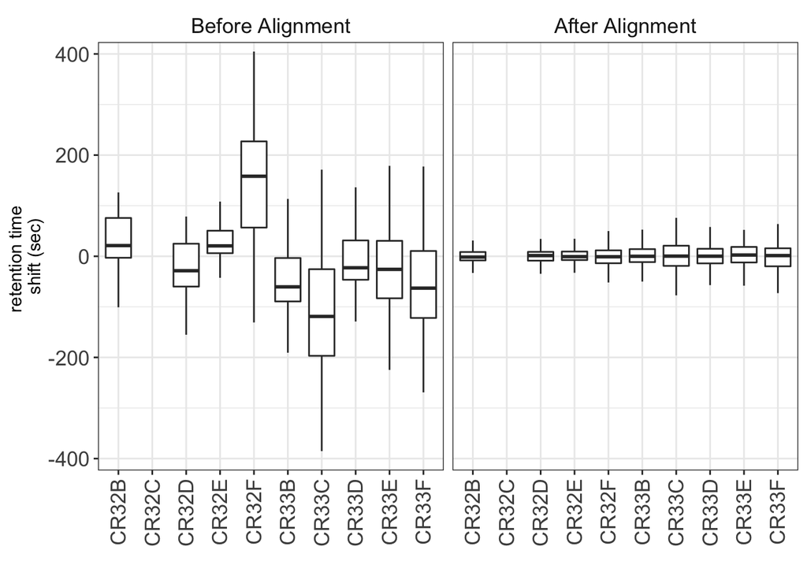

```r
# Create deviation boxplots ----------------------------------------------------

short_names <- c(
  "CR32B", "CR32C", "CR32D", "CR32E", "CR32F",
  "CR33B", "CR33C", "CR33D", "CR33E", "CR33F"
)

# Create a list that will hold the reference, current, predicted (aligned), and
# smoothed (predicted line) values.
z <- vector(mode = "list",
            length = length(ds_names))

# Grab the name of the reference data set.
ref_ds <- find_ref_ds(ms2_art)

# Loop through each data set and fill in the retention time values.
for (e in 1:length(ds_names)) {

  cur_ds <- ds_names[[e]]

  # Subset the original data set into the reference and current data sets.
  x_ref <- ms2_ipf %>%
    filter(Dataset == ref_ds) %>%
    dplyr::distinct(`Feature intensity`, `Feature apex`, Proteoform) %>%
    dplyr::group_by(Proteoform) %>%
    dplyr::slice_max(`Feature intensity`) %>%
    dplyr::slice_min(`Feature apex`)
  x_cur <- ms2_art %>%
    filter(Dataset == cur_ds) %>%
    dplyr::distinct(
      `Feature intensity`, `Feature apex`, Proteoform, RTalign
    ) %>%
    dplyr::group_by(Proteoform) %>%
    dplyr::slice_max(`Feature intensity`) %>%
    dplyr::slice_min(`Feature apex`)

  # Find the proteoforms that occur in both CR32C and CR33C. This vector will be
  # used to subset the aligned retention times from the current data matrix.
  both <- intersect(x_ref$Proteoform, x_cur$Proteoform)

  # Extract the indices where the intersecting Proteoforms occur in both the
  # reference data set and the current data set.
  idx_ref <- which(x_ref$Proteoform %in% both)
  idx_cur <- which(x_cur$Proteoform %in% both)

  aligned <- x_cur$RTalign[idx_cur]

  temp <- data.frame(
    reference = x_ref$`Feature apex`[idx_ref],
    current = x_cur$`Feature apex`[idx_cur],
    dataset = short_names[[e]]
  )

  temp$predicted <- predict(the_model[[cur_ds]], newdata = temp$current)
  temp$deviation_before <- temp$reference - temp$current
  temp$deviation_after <- temp$reference - temp$predicted

  z[[e]] <- temp

}

big_z <- data.table::rbindlist(z) %>%
  as.data.frame()

before_z <- big_z[, c("dataset", "deviation_before")]
before_z$when <- "Before Alignment"
names(before_z)[2] <- "deviation"
after_z <- big_z[, c("dataset", "deviation_after")]
after_z$when <- "After Alignment"
names(after_z)[2] <- "deviation"

tall_z <- rbind(before_z, after_z)
tall_z$when <- factor(tall_z$when,
                      levels = c("Before Alignment",
                                 "After Alignment"))

# Remove anything from the reference data set because we do not want it plotted.
tall_z$deviation[which(tall_z$dataset == "CR32C")] <- NA

ggplot(tall_z,
       aes(x = dataset, y = deviation)) +
  geom_boxplot(outlier.shape = NA) +
  coord_cartesian(ylim = c(-385, 385)) +
  facet_wrap(~when) +
  theme_bw() +
  theme(strip.background = element_blank(),
        axis.text.x = element_text(angle = 90, vjust = 0.5, hjust=1),
        axis.text = element_text(size = 13),
        strip.text.x = element_text(size = 13)) +
  xlab("") +
  ylab("retention time \nshift (sec)")
```

### 2D

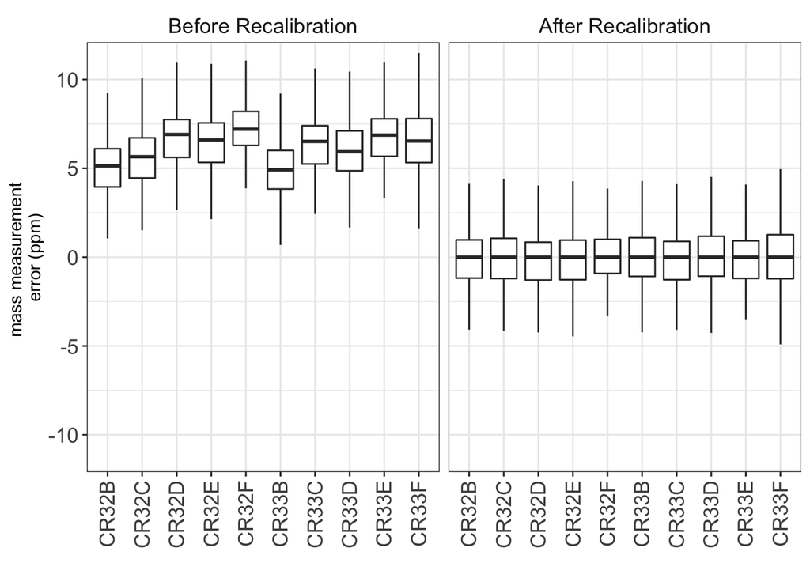

```r
# Create before/after ppm error box plots --------------------------------------

before <- ms2_rcm %>%
  dplyr::filter(`#unexpected modifications` == 0) %>%
  dplyr::filter(abs(`Precursor mass` - `Adjusted precursor mass`) < 0.5) %>%
  dplyr::mutate(
    split_dataset = str_split(Dataset, "_"),
    Dataset = map(split_dataset, `[[`, 3),
    Dataset = as.character(Dataset),
    ppm_error = 1e6 * (`Precursor mass` - `Adjusted precursor mass`) /
      `Adjusted precursor mass`,
    when = "Before Recalibration"
  ) %>%
  select(Dataset, ppm_error, when)

after <- ms2_rcm %>%
  dplyr::filter(`#unexpected modifications` == 0) %>%
  dplyr::filter(abs(`Precursor mass` - `Adjusted precursor mass`) < 0.5) %>%
  dplyr::mutate(
    split_dataset = str_split(Dataset, "_"),
    Dataset = map(split_dataset, `[[`, 3),
    Dataset = as.character(Dataset),
    ppm_error = 1e6 * (RecalMass - `Adjusted precursor mass`) /
      `Adjusted precursor mass`,
    when = "After Recalibration"
  ) %>%
  select(Dataset, ppm_error, when)

both <- rbind(before, after)

both$when <- factor(both$when,
                    levels = c("Before Recalibration",
                               "After Recalibration"))

ggplot(both,
       aes(x = Dataset, y = ppm_error)) +
  geom_boxplot(outlier.shape = NA) +
  coord_cartesian(ylim = c(-11, 11)) +
  facet_wrap(~when) +
  theme_bw() +
  theme(strip.background = element_blank(),
        axis.text.x = element_text(angle = 90, vjust = 0.5, hjust=1),
        axis.text = element_text(size = 13),
        strip.text.x = element_text(size = 13)) +
  xlab("") +
  ylab("mass measurement \nerror (ppm)")
```

## Figure 3

### 3a

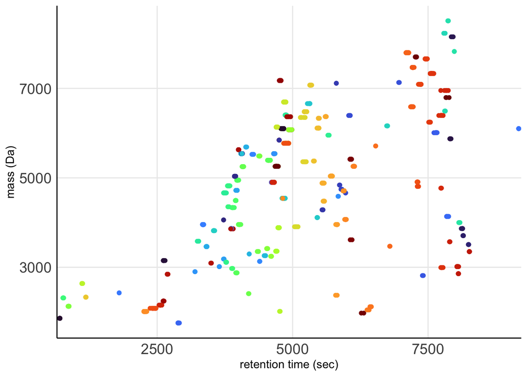

```r
# Cluster: GAPDH ---------------------------------------------------------------

# Extract the gene in question.
x_gene <- ms2_grp %>%
  filter(Gene == "GAPDH")

# Clusters present in the zoomed in portion of the main graph.
keepers <- c(31, 33, 34, 35, 37, 40, 41, 43, 44, 89, 90, 92, 93, 108) %>%
  as.character() %>%
  factor() %>%
  levels() %>%
  as.numeric()

keepers_df <- filter(x_gene, cluster %in% keepers)

# Assign custom colors to the clusters in the zoomed portion. This data frame
# will be used to color these clusters in each of the plots.
color_df <- data.frame(
  cluster = keepers,
  colors = c("#25ECA7", "#62FC6B", "#DA3907", "#39A5FB", "#7A0403", "#D1E935",
             "#30123B", "#1CCFD5", "#F46516", "#B21A01", "#4777EF", "#4146AD",
             "#FE9B2D", "#A3FD3C")
)

keepers_df_w_color <- inner_join(keepers_df, color_df)

ggplot(data = x_gene,
       aes(x = RTalign,
           y = RecalMass,
           color = as.character(cluster))) +
  geom_point() +
  theme_bw() +
  theme(panel.border = element_blank(),
        panel.grid.minor = element_blank(),
        axis.line = element_line(colour = "black"),
        axis.ticks = element_blank(),
        axis.text = element_text(size = 14),
        strip.background = element_rect(colour = "white",
                                        fill = "white"),
        legend.position = "none") +
  scale_x_continuous(expand = c(0, 0), limits = c(650, 9220)) +
  xlab("") +
  ylab("") +
  scale_color_manual(
    values = TopPICR:::turbo(n = n_distinct(x_gene$cluster))
  ) +
  geom_point(
    data = keepers_df,
    color = keepers_df_w_color$colors
  ) +
  xlab("retention time (sec)") +
  ylab("mass (Da)")
```

### 3b

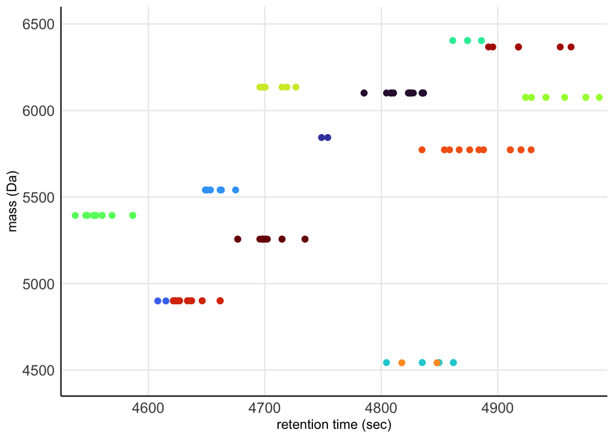

```r
ggplot(data = keepers_df,
       aes(x = RTalign,
           y = RecalMass,
           color = as.character(cluster))) +
  geom_point(size = 2) +
  theme_bw() +
  theme(panel.border = element_blank(),
        panel.grid.minor = element_blank(),
        axis.line = element_line(colour = "black"),
        axis.ticks = element_blank(),
        axis.text = element_text(size = 12),
        strip.background = element_rect(colour = "white",
                                        fill = "white"),
        legend.position = "none") +
  scale_x_continuous(expand = c(0, 0), limits = c(4525, 4994)) +
  scale_y_continuous(expand = c(0, 0), limits = c(4350, 6600)) +
  xlab("retention time (sec)") +
  ylab("mass (Da)") +
  scale_color_manual(
    values = color_df$colors
  )
```

### 3c

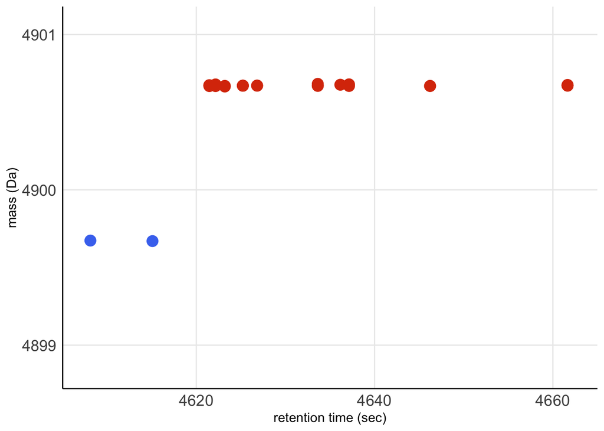

```r
point_size <- 4

ggplot(data = keepers_df,
       aes(x = RTalign,
           y = RecalMass,
           color = as.character(cluster))) +
  geom_point(size = point_size) +
  theme_bw() +
  theme(panel.border = element_blank(),
        panel.grid.minor = element_blank(),
        axis.line = element_line(colour = "black"),
        axis.ticks = element_blank(),
        axis.text = element_text(size = 13),
        strip.background = element_rect(colour = "white",
                                        fill = "white"),
        legend.position = "none") +
  scale_x_continuous(expand = c(0, 0), limits = c(4605, 4665)) +
  scale_y_continuous(
    expand = c(0, 0),
    limits = c(4898.72, 4901.18),
    breaks = c(4899, 4900, 4901)
  ) +
  xlab("retention time (sec)") +
  ylab("mass (Da)") +
  scale_color_manual(
    values = color_df$colors
  )
```

### 3d

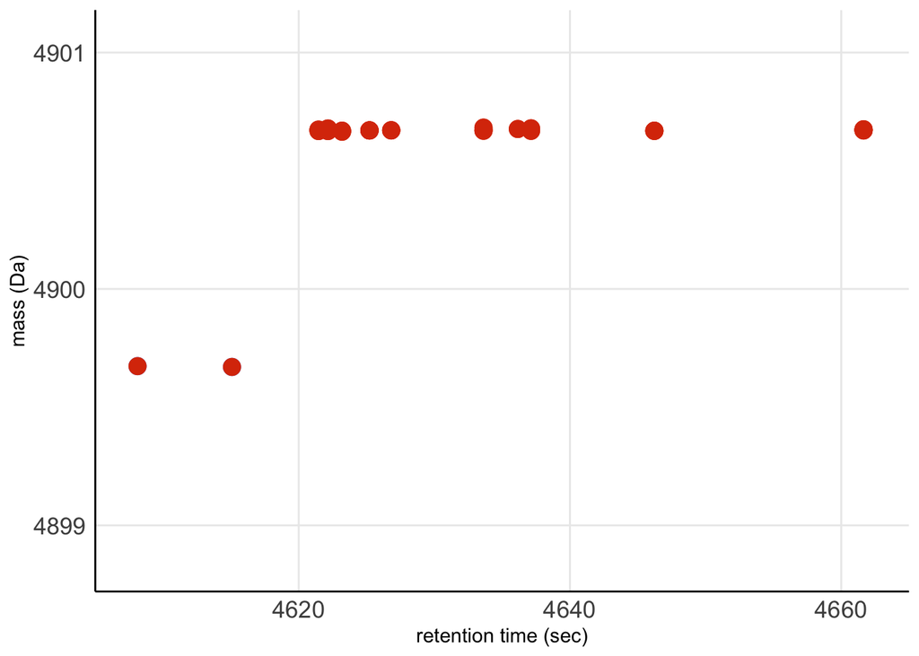

```r
ggplot(data = keepers_df,
       aes(x = RTalign,
           y = RecalMass,
           color = as.character(cluster))) +
  geom_point(size = point_size) +
  theme_bw() +
  theme(panel.border = element_blank(),
        panel.grid.minor = element_blank(),
        axis.line = element_line(colour = "black"),
        axis.ticks = element_blank(),
        axis.text = element_text(size = 13),
        strip.background = element_rect(colour = "white",
                                        fill = "white"),
        legend.position = "none") +
  scale_x_continuous(expand = c(0, 0), limits = c(4605, 4665)) +
  scale_y_continuous(
    expand = c(0, 0),
    limits = c(4898.72, 4901.18),
    breaks = c(4899, 4900, 4901)
  ) +
  xlab("retention time (sec)") +
  ylab("mass (Da)") +
  scale_color_manual(
    values = color_df$colors
  ) +
  geom_point(
    data = filter(x_gene, pcGroup == 33),
    size = point_size,
    color = filter(color_df, cluster == 33) %>% pull(colors)
  )
```

### 3e

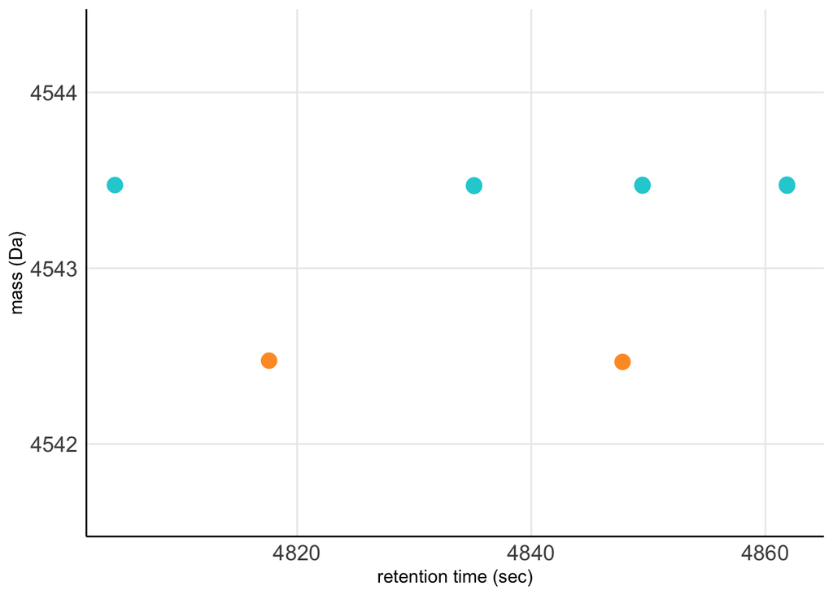

```r
ggplot(data = keepers_df,
       aes(x = RTalign,
           y = RecalMass,
           color = as.character(cluster))) +
  geom_point(size = point_size) +
  theme_bw() +
  theme(panel.border = element_blank(),
        panel.grid.minor = element_blank(),
        axis.line = element_line(colour = "black"),
        axis.ticks = element_blank(),
        axis.text = element_text(size = 13),
        strip.background = element_rect(colour = "white",
                                        fill = "white"),
        legend.position = "none") +
  scale_x_continuous(expand = c(0, 0), limits = c(4802, 4865)) +
  scale_y_continuous(
    expand = c(0, 0),
    limits = c(4541.474, 4544.474),
    breaks = c(4542, 4543, 4544)
  ) +
  xlab("retention time (sec)") +
  ylab("mass (Da)") +
  scale_color_manual(
    values = color_df$colors
  )
```

### 3f

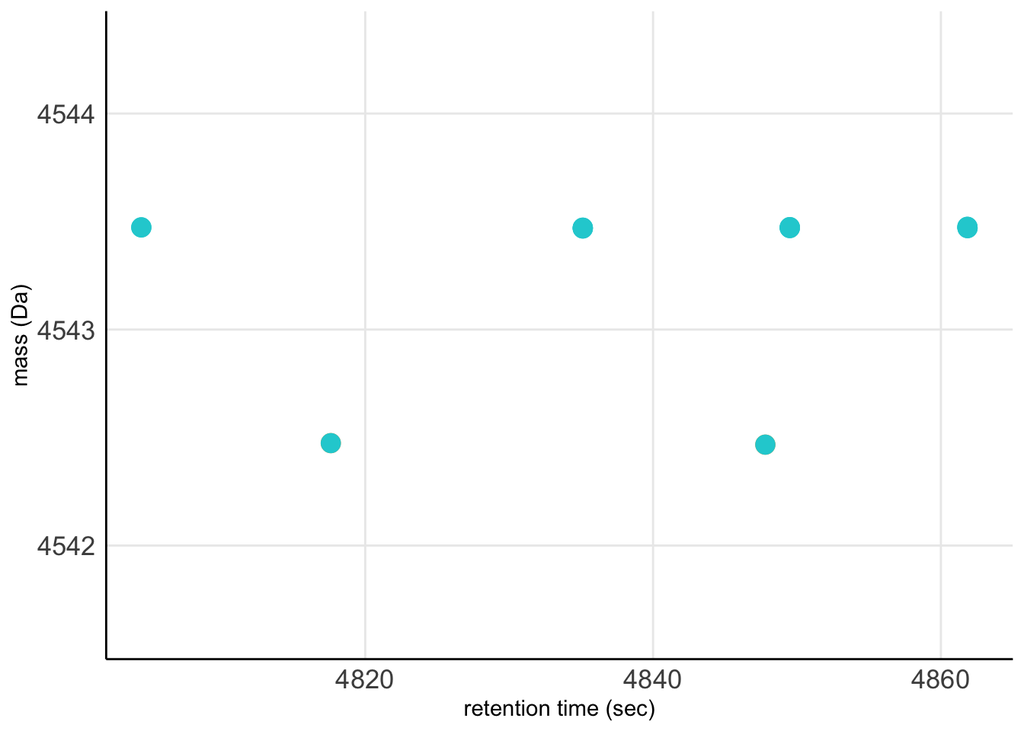

```r
ggplot(data = keepers_df,
       aes(x = RTalign,
           y = RecalMass,
           color = as.character(cluster))) +
  geom_point(size = point_size) +
  theme_bw() +
  theme(panel.border = element_blank(),
        panel.grid.minor = element_blank(),
        axis.line = element_line(colour = "black"),
        axis.ticks = element_blank(),
        axis.text = element_text(size = 13),
        strip.background = element_rect(colour = "white",
                                        fill = "white"),
        legend.position = "none") +
  scale_x_continuous(expand = c(0, 0), limits = c(4802, 4865)) +
  scale_y_continuous(
    expand = c(0, 0),
    limits = c(4541.474, 4544.474),
    breaks = c(4542, 4543, 4544)
  ) +
  xlab("retention time (sec)") +
  ylab("mass (Da)") +
  scale_color_manual(
    values = color_df$colors
  ) +
  geom_point(
    data = filter(x_gene, pcGroup == 41),
    size = point_size,
    color = filter(color_df, cluster == 41) %>% pull(colors)
  )
```

## Figure 4

Code to reproduce the proteoform level plot. The function that computed the proteoform level can be found in the MS2 steps section.

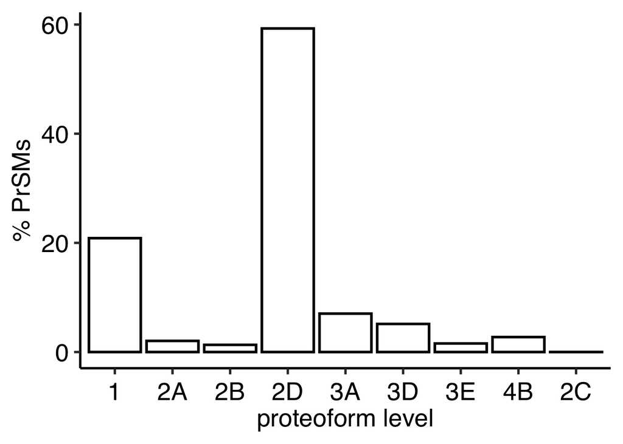

```r
ms2_pfl %>%
  group_by(`Proteoform Level`) %>%
  add_count(name = "n") %>%
  distinct(`Proteoform Level`, n) %>%
  ungroup() %>%
  mutate(total = sum(n)) %>%
  group_by(`Proteoform Level`) %>%
  mutate(Percentage = n/total*100) %>%
  ggplot() +
  aes(x = fct_relevel(`Proteoform Level`, "1", "2A","2B", "2D", "3A",
                      "3D", "3E", "4A", "4B", "5"),
      y = Percentage
  ) +
  geom_bar(stat = "identity",
           show.legend = FALSE,
           size = 1,
           fill = "white",
           color = "black") +
  theme_bw(base_size = 20) +
  theme(panel.background = element_rect(fill= 'white'),
        axis.text.y = element_text(color = 'black', size = 20),
        axis.text.x = element_text(angle = 0,
                                   vjust = 0.5,
                                   hjust = 0.5,
                                   color = 'black',
                                   size = 20),
        panel.grid.minor = element_blank(),
        panel.grid.major = element_blank(),
        panel.border = element_blank(),
        axis.line = element_line(),
        text = element_text(family = "Helvetica")) +
  ylab("% PrSMs") +
  xlab("proteoform level")
```

```r
# ggsave("pflevel.png", width = 10, height = 5)
ggsave(filename = "figure_4.pdf",
       width = 10,
       height = 5,
       units = "in",
       dpi = "retina")
```

## Figure 5

The code for the PTM preprocessing steps and reproducing the PTM plot.

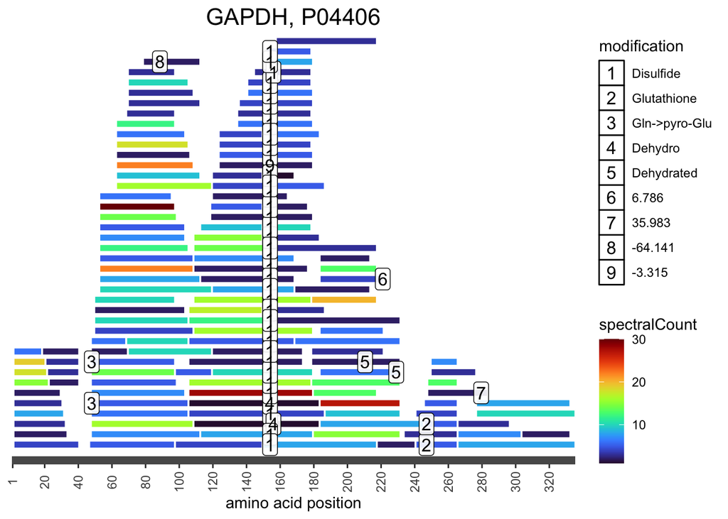

```r
uni_top <- create_mod_data(
  mod_file = "TopPIC_Variable_Mods.txt",
  mod_path = file.path(the_path, "TopPIC_output/")
)

x_mods <- add_mods(x = meta,
                   mods = uni_top,
                   nterm_tol = 3,
                   acetyl_id = "Acetyl",
                   centroid_tol = 0.57,
                   matching_tol = 0.1)

plot_accession_ptm(x = x_mods,
                   accession = "P04406",
                   mods_to_name = "top10",
                   aa_step = 20) +
    xlab("amino acid position")
```

## Figure 6

Code to reproduce the statistical analysis figure from the manuscript. The following code just reproduces the plots. The code for the actual analysis is in the Statistical analysis section.

### 6a

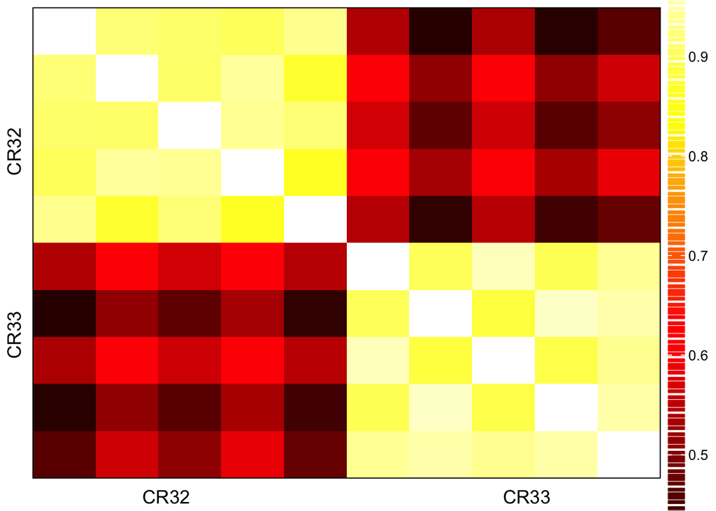

```r
exprs(m0) <- log2(exprs(m0))

complex_heatmap(
    m0,
    heatmap_type = "sample",
    cluster_columns = F,
    cluster_rows = F,
    heatmap_args = list(
        col = circlize::colorRamp2(
            breaks = seq(0.4, 1, length.out = 100),
            colors = MSnSet.utils::hot.colors(100)
        ),
        row_title = "CR33                          CR32",
        column_title = "CR32                                                            CR33",
        column_title_side = "bottom",
        heatmap_legend_param = list(
            legend_height = unit(150, "mm"),
            legend_width = unit(20, "mm"),
            at = seq(0.4, 1, length.out = 7)
        )
    )
)
```

### 6b

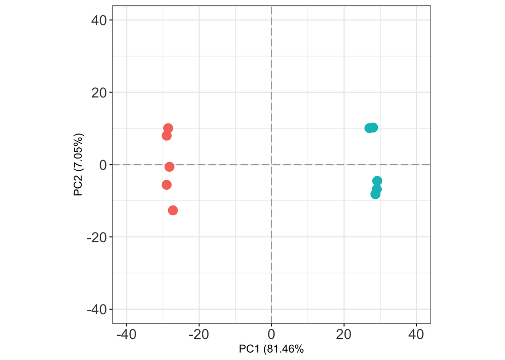

```r
plot_pca(
  m,
  phenotype = "group",
  legend_title = "group",
  show_ellipse = F,
  size = 4,
  standardize = F
) +
  theme(
    legend.position = "none",
    axis.text = element_text(size = 14)
  ) +
  xlim(-40, 40) +
  ylim(-40, 40) +
  xlab("PC1 (81.46%") +
  ylab("PC2 (7.05%)")
```

### 6c

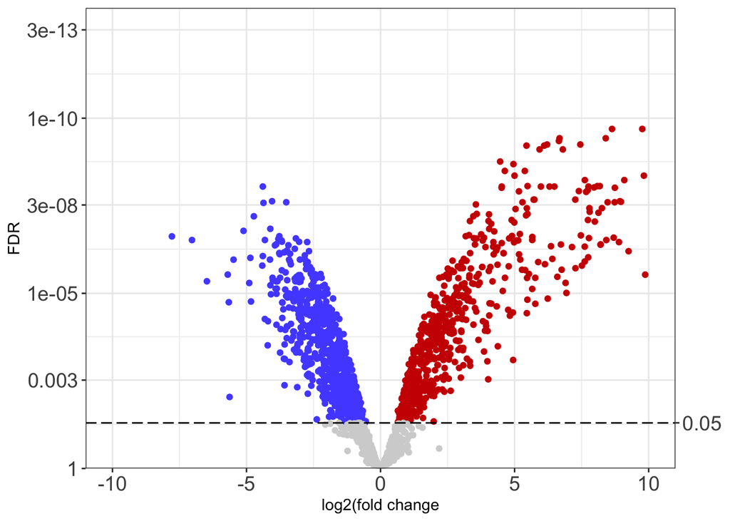

```r
plot_volcano(
  res,
  logFC = "logFC",
  pvals = "adj.P.Val",
  sig_threshold = 0.05,
  point_args = list(mapping = aes(color = point_color))
) +
  xlim(-10, 10) +
  scale_color_manual(
    values = c("#5555ff", "red3", "lightgrey"),
    breaks = c("down", "up", "NS")
  ) +
  theme(
    legend.position = "none",
    axis.text = element_text(size = 14)
  ) +
  xlab("log2(fold change") +
  ylab("FDR")
```

# Code to reproduce tables

## Table 1

The code to calculate the counts and FDR found in Table 1 of the manuscript. It is important to note that the definition of proteoform is different for the Cluster and Isotopologue cluster columns. Therefore, the method/functions for calculating the counts and FDR for these columns is different from the method/functions used to calculate these values for the other four columns (No filter, Occurrence filter, E-value filter, and Inference).

### Counts

```r
# Count unique PrSMs, proteoforms, sequences, and genes ------------------------

# Count: no filter ---------------

count_mp <- c(
# Count the number of unique PrSMs.
ms2_mp %>%
  distinct(Dataset, `Scan(s)`) %>%
  nrow(),
# Count the number of unique proteoforms.
ms2_mp %>%
  distinct(Proteoform) %>%
  nrow(),
# Count the number of unique amino acid sequences.
ms2_mp %>%
  distinct(cleanSeq) %>%
  nrow(),
# Count the number of unique genes.
ms2_mp %>%
  distinct(Gene) %>%
  nrow()
)

# Count: occurrence filter ---------------

count_fbc <- c(
# Count the number of unique PrSMs.
ms2_fbc %>%
  distinct(Dataset, `Scan(s)`) %>%
  nrow(),
# Count the number of unique proteoforms.
ms2_fbc %>%
  distinct(Proteoform) %>%
  nrow(),
# Count the number of unique amino acid sequences.
ms2_fbc %>%
  distinct(cleanSeq) %>%
  nrow(),
# Count the number of unique genes.
ms2_fbc %>%
  distinct(Gene) %>%
  nrow()
)

# Count: E-value cutoff filter ---------------

count_fdr <- c(
# Count the number of unique PrSMs.
ms2_fdr %>%
  distinct(Dataset, `Scan(s)`) %>%
  nrow(),
# Count the number of unique proteoforms.
ms2_fdr %>%
  distinct(Proteoform) %>%
  nrow(),
# Count the number of unique amino acid sequences.
ms2_fdr %>%
  distinct(cleanSeq) %>%
  nrow(),
# Count the number of unique genes.
ms2_fdr %>%
  distinct(Gene) %>%
  nrow()
)

# Count: proteoform inference ---------------

count_ipf <- c(
# Count the number of unique PrSMs.
ms2_ipf %>%
  distinct(Dataset, `Scan(s)`) %>%
  nrow(),
# Count the number of unique proteoforms.
ms2_ipf %>%
  distinct(Proteoform) %>%
  nrow(),
# Count the number of unique amino acid sequences.
ms2_ipf %>%
  distinct(cleanSeq) %>%
  nrow(),
# Count the number of unique genes.
ms2_ipf %>%
  distinct(Gene) %>%
  nrow()
)

# Count: cluster ---------------

count_clu <- c(
# Count the number of unique PrSMs.
ms2_clu %>%
  filter(cluster != 0) %>%
  distinct(Dataset, `Scan(s)`) %>%
  nrow(),
# Count the number of unique proteoforms.
ms2_clu %>%
  filter(cluster != 0) %>%
  distinct(Gene, cluster) %>%
  nrow(),
# Count the number of unique amino acid sequences.
ms2_clu %>%
  filter(cluster != 0) %>%
  distinct(cleanSeq) %>%
  nrow(),
# Count the number of unique genes.
ms2_clu %>%
  filter(cluster != 0) %>%
  distinct(Gene) %>%
  nrow()
)

# Count: cluster groups ---------------

count_grp <- c(
# Count the number of unique PrSMs.
ms2_grp %>%
  distinct(Dataset, `Scan(s)`) %>%
  nrow(),
# Count the number of unique proteoforms.
ms2_grp %>%
  distinct(Gene, pcGroup) %>%
  nrow(),
# Count the number of unique amino acid sequences.
ms2_grp %>%
  distinct(cleanSeq) %>%
  nrow(),
# Count the number of unique genes.
ms2_grp %>%
  distinct(Gene) %>%
  nrow()
)

# Create a data frame with counts that can be passed to the kable function.
table_counts <- data.frame(
  `No filter` = count_mp,
  `Occurrence filter` = count_fbc,
  `E-value filter` = count_fdr,
  Inference = count_ipf,
  Cluster = count_clu,
  `Isotopologue cluster` = count_grp,
  check.names = FALSE
) %>%
  `rownames<-`(c("PrSM", "Proteoform", "AA sequence", "Gene"))

# The following line reproduces the markdown table shown below.
# knitr::kable(table_counts)
```

|  | No filter | Occurrence filter | E-value filter | Inference | Cluster | Isotopologue cluster |
| --- | --- | --- | --- | --- | --- | --- |
| PrSM | 23136 | 21697 | 21647 | 21610 | 20980 | 20980 |
| Proteoform | 6878 | 5439 | 5419 | 5419 | 2705 | 2451 |
| AA sequence | 3679 | 2240 | 2225 | 2225 | 2158 | 2158 |
| Gene | 1482 | 908 | 893 | 556 | 527 | 527 |

### FDR

```r
# Compute FDR ------------------------------------------------------------------

# NOTE: The counts from the compute_fdr function will be different from the
# counts above because it only counts the number of non-decoy hits. Whereas the
# counts from above include both non-decoy and decoy hits.
#
# NOTE: We do not include the counts or FDR at the accession level.

fdr_mp <- compute_fdr(ms2_mp)
fdr_fbc <- compute_fdr(ms2_fbc)
fdr_fdr <- compute_fdr(ms2_fdr)
fdr_ipf <- compute_fdr(ms2_ipf)
# For the following two lines we don't use the Proteoform FDR because the
# definition of a proteoform changes to Gene_cluster and Gene_pcGroup
# respectively.
fdr_clu <- compute_fdr(filter(ms2_clu, cluster != 0))
fdr_grp <- compute_fdr(ms2_grp)

# Proteoform (Gene_cluster) FDR.
fdr_clu_pf <- ms2_clu %>%
  filter(cluster != 0) %>%
  distinct(Gene, cluster, isDecoy) %>%
  summarize(fdr = mean(isDecoy)) %>%
  pull(fdr) * 100

# Proteoform (Gene_pcGroup) FDR.
fdr_grp_pf <- ms2_grp %>%
  distinct(Gene, pcGroup, isDecoy) %>%
  summarize(fdr = mean(isDecoy)) %>%
  pull(fdr) * 100

# Create a data frame with FDR values that can be passed to the kable function.
table_fdr <- data.frame(
  `No filter` = unname(unlist(lapply(fdr_mp, `[[`, 1)))[c(1:3, 5)],
  `Occurrence filter` = unname(unlist(lapply(fdr_fbc, `[[`, 1)))[c(1:3, 5)],
  `E-value filter` = unname(unlist(lapply(fdr_fdr, `[[`, 1)))[c(1:3, 5)],
  Inference = unname(unlist(lapply(fdr_ipf, `[[`, 1)))[c(1:3, 5)],
  Cluster = c(
    unname(unlist(lapply(fdr_clu, `[[`, 1)))[1],
    fdr_clu_pf,
    unname(unlist(lapply(fdr_clu, `[[`, 1)))[c(3, 5)]
  ),
  `Isotopologue cluster` = c(
    unname(unlist(lapply(fdr_grp, `[[`, 1)))[1],
    fdr_grp_pf,
    unname(unlist(lapply(fdr_grp, `[[`, 1)))[c(3, 5)]
  ),
  check.names = FALSE
) %>%
  `rownames<-`(c("PrSM", "Proteoform", "AA sequence", "Gene"))

# The following line reproduces the markdown table shown below.
# knitr::kable(round(table_fdr, 3))
```

|  | No filter | Occurrence filter | E-value filter | Inference | Cluster | Isotopologue cluster |
| --- | --- | --- | --- | --- | --- | --- |
| PrSM | 1.253% | 0.221% | 0.079% | 0.079% | 0.048% | 0.048% |
| Proteoform | 3.838% | 0.404% | 0.129% | 0.129% | 0.111% | 0.122% |
| AA sequence | 7.094% | 0.848% | 0.315% | 0.315% | 0.139% | 0.139% |
| Gene | 17.057% | 2.090% | 0.784% | 1.259% | 0.569% | 0.569% |

# Percentage of missing data

In the manuscript we state that the match-between-runs (MBR) step reduces the percentage of missing data compared to not using this method. Below is the code we used to calculate the percentage of missing data for both methods (with MBR and without MBR).

```r
# To create an msnset object there can only be one feature intensity value.
# Remove extras by taking the maximum across Dataset, CV, Gene, and pcGroup.
x_grp <- ms2_grp %>%
  group_by(Dataset, CV, Gene, pcGroup) %>%
  summarize(
    Intensity = max(`Feature intensity`, na.rm = TRUE)
  )

# Create an msnset object with the data prior to the MBR step. We will use this
# to compare the amount of missing data the MBR step reduces.
m_no_mbr <- to_msnset(x_grp, meta)

# Compute the proportion of missing data WITHOUT the MBR step.
prop_no_mbr <- sum(is.na(exprs(m_no_mbr))) / prod(dim(exprs(m_no_mbr))) * 100

# Compute the proportion of missing data WITH the MBR step.
prop_mbr <- sum(is.na(exprs(m0))) / prod(dim(exprs(m0))) * 100
```

The percentage of missing data without the MBR step is 54.34% and with the MBR step it is 22.8%.